# Actividad 2

2025-12-01

## 1. Replicar el gráfico

Replique un gráfico de forma eficiente.

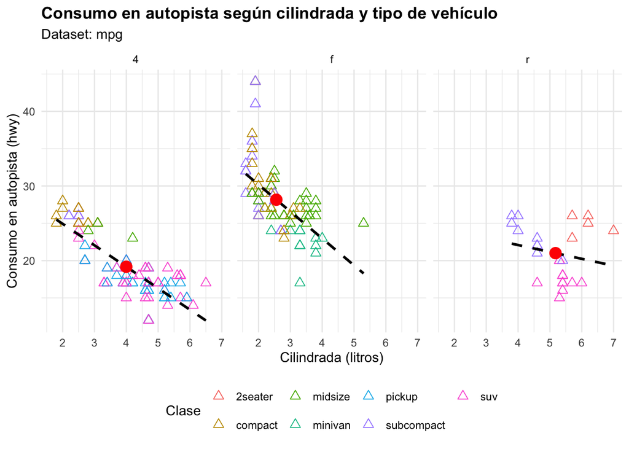

```r
library(ggplot2)
library(dplyr)
m <- mpg %>% group_by(drv) %>% summarise(x=mean(displ),y=mean(hwy))
ggplot(mpg,aes(displ,hwy,color=class))+
  geom_point(size=2.5,shape=2)+
  geom_smooth(aes(displ,hwy),method="lm",se=FALSE,col="black",lty=2)+
  geom_point(data=m,aes(x,y),col="red",size=4)+
  facet_wrap(~drv)+
  labs(title="Consumo en autopista según cilindrada y tipo de vehículo",
       subtitle="Dataset: mpg",
       x="Cilindrada (litros)",y="Consumo en autopista (hwy)",color="Clase")+
  theme_minimal()+
  theme(plot.title=element_text(face="bold"),legend.position="bottom")
```

## 2. Mapa de Europa

Haz un mapa de Europa coloreando cada país según su población estimada (pop_est), usando los datos obtenidos con ne_countries(). Los países más poblados deben aparecer en colores más intensos. Añade título, leyenda y un estilo limpio.

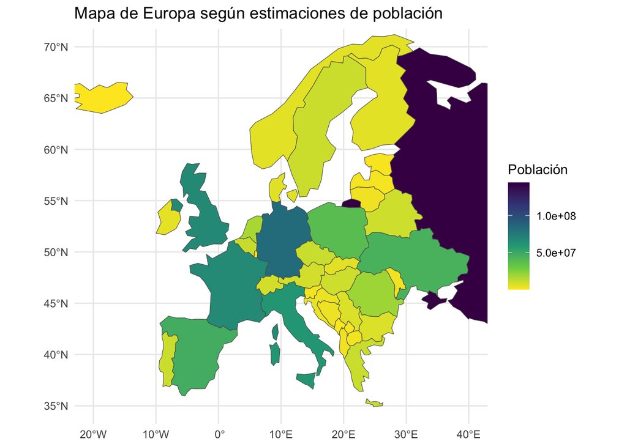

```r
library(rnaturalearth)
library(ggplot2)
Europe <- ne_countries(continent="Europe")
ggplot(Europe)+
  geom_sf(aes(fill=pop_est))+
  coord_sf(xlim=c(-20,40),ylim=c(35,70))+
  labs(title="Mapa de Europa según estimaciones de población",
       fill="Población")+
  scale_fill_viridis_c(direction=-1)+
  theme_minimal()
```

## 3. Función de clasificación

Genere una función llamada clasificar_flores() que reciba el dataset iris (instalado en R) por defecto y cree una nueva variable llamada tamaño_petalo, de forma que si la variable Petal.Length es mayor a 4 devuelva “Largo” y en caso contrario devuelva “Corto”. Especificaciones: - Use un bucle para recorrer las filas. - Use if/else para clasificar. - Devuelva el dataset con la nueva columna.

```r
clasificar_flores <- function(iris) {
  tamaño_petalo <- c()
  for (i in 1:nrow(iris)) {
    if (iris$Petal.Length[i] > 4) {
      tamaño_petalo[i] <- "Largo"
    } else {
      tamaño_petalo[i] <- "Corto"
    }
  }
  iris$tamaño_petalo <- tamaño_petalo
  return(iris)
}
nuevo_iris <- clasificar_flores(iris)
head(nuevo_iris,10)
```

```
##    Sepal.Length Sepal.Width Petal.Length Petal.Width Species tamaño_petalo
## 1           5.1         3.5          1.4         0.2  setosa         Corto
## 2           4.9         3.0          1.4         0.2  setosa         Corto
## 3           4.7         3.2          1.3         0.2  setosa         Corto
## 4           4.6         3.1          1.5         0.2  setosa         Corto
## 5           5.0         3.6          1.4         0.2  setosa         Corto
## 6           5.4         3.9          1.7         0.4  setosa         Corto
## 7           4.6         3.4          1.4         0.3  setosa         Corto
## 8           5.0         3.4          1.5         0.2  setosa         Corto
## 9           4.4         2.9          1.4         0.2  setosa         Corto
## 10          4.9         3.1          1.5         0.1  setosa         Corto
```

## 4. Simulación

En este ejercicio vamos a programar una pequeña simulación divertida. La máquina intentará adivinar un número secreto entre 1 y 50. Genere una función adivina_numero() que: - Elija un número arbitrario entre 1 y 50 (no lo muestre hasta el final).  
- La máquina tiene 10 intentos para adivinar el resultado.  
- En cada intento:  
i. Si adivina, devuelve “Enhorabuena, has encontrado el número __ en ___ intentos”.  
ii. Si el número es más alto que el propuesto, devuelva “Alto” y vuelva a elegir un número entre 1 y el número secreto - 1.  
iii. Si el número es más bajo que el propuesto, devuelva “Bajo” y vuelva a elegir un número entre el número secreto +1 y 50.

```r
adivina_numero <- function() {
numero <- sample(1:50,1)
L1 <- 1
L2 <- 50
  for (i in 1:10) {
    guess <- sample(L1:L2,1)
  if (guess==numero) {
      return(paste("Enhorabuena, has encontrado el número", numero,
                   "en", i, "intentos"))
    }
    if (guess>numero) {
      cat("Alto, ")
      L2 <- guess - 1
    } else {
      cat("Bajo, ")
      L1 <- guess + 1
    }
  }
}
adivina_numero()
```

```
## Alto, Alto, Alto, Bajo,
```

```
## [1] "Enhorabuena, has encontrado el número 20 en 5 intentos"
```

## 5. Simulación probabilidad

Simule 10 mil valores de una distribución N(50,102). Calcule la probabilidad de que la variable tome valores superiores a 60.

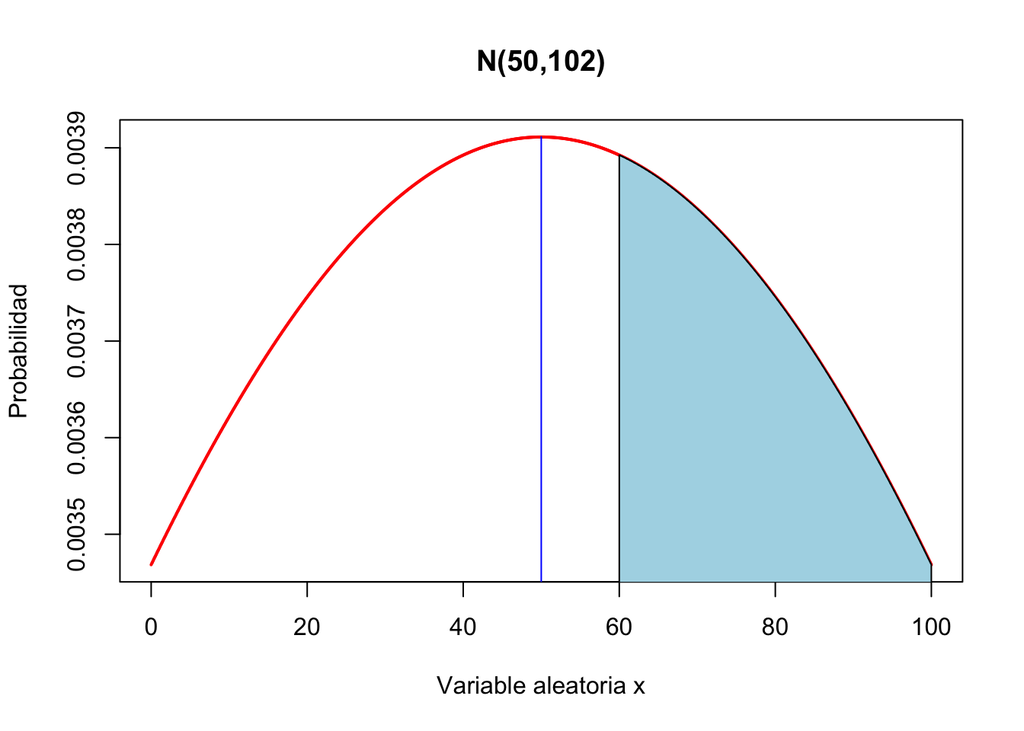

```r
L1 <- c(60,seq(60,100,0.0038),100)
L2 <- c(0,dnorm(seq(60,100,0.0038),mean=50,sd=102),0)

x <- seq(0,100, 0.001)
y <- dnorm(x,mean=50,sd=102)
plot(x,y,ylab="Probabilidad",xlab="Variable aleatoria x",main="N(50,102)",type="l",
     col="red",lty=1,lwd=2)

segments(50,0,50,dnorm(x=50,mean=50,sd=102),lty=1,col="blue")

polygon(L1,L2,col="lightblue")
```

```r
p <- pnorm(60,mean=50,sd=102,lower.tail=FALSE)
paste("La probabilidad de que la variable tome valores superiores a 60 es del", p*100,"%")
```

```
## [1] "La probabilidad de que la variable tome valores superiores a 60 es del 46.0950576865208 %"
```

## 6. Teorema central del límite

En estadística, el Teorema Central del Límite indica que muchas distribuciones, bajo ciertas condiciones, tienden a aproximarse a una distribución normal. En este ejercicio deberás simular datos de dos distribuciones diferentes: Uniforme y Poisson. Explica en qué casos y por qué estas distribuciones se aproximan a una normal.

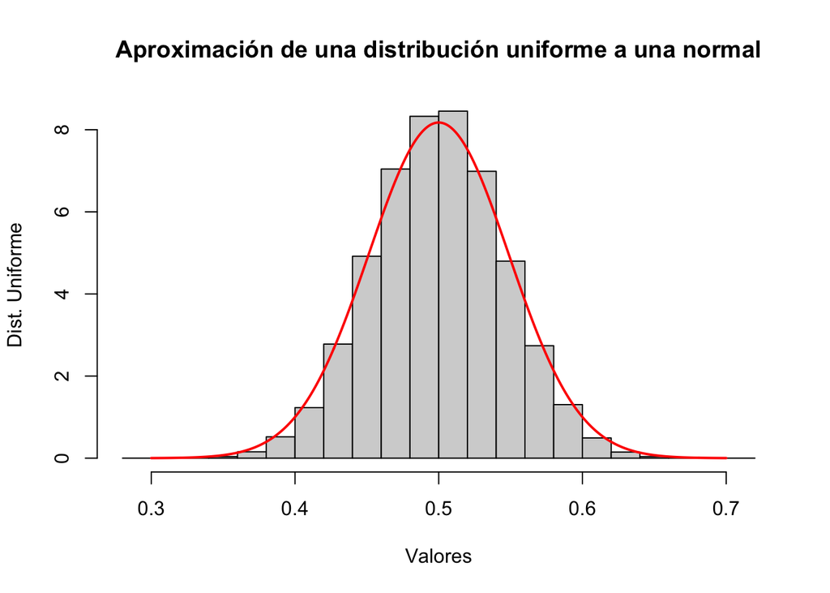

```r
muestra <- runif(40,0,1)
mean <- 5
sd <- 1
means <- rep(0,100000)
for(i in 1:100000){
  muestra <- runif(40,0,1)
  means[i] <- mean(muestra)
}
hist(means,freq=FALSE,
     main="Aproximación de una distribución uniforme a una normal",
     xlab="Valores",ylab="Dist. Uniforme")

x <- seq(0.3,0.7,0.001)
lines(x,dnorm(x,mean=0.5,sd=1/sqrt(12*35)),col="red",lwd=2)
```

La media de un gran número de variables aleatorias independientes con distribución uniforme se puede aproximar por una distribución normal cuando el número de variables es más de 30 (generalmente).

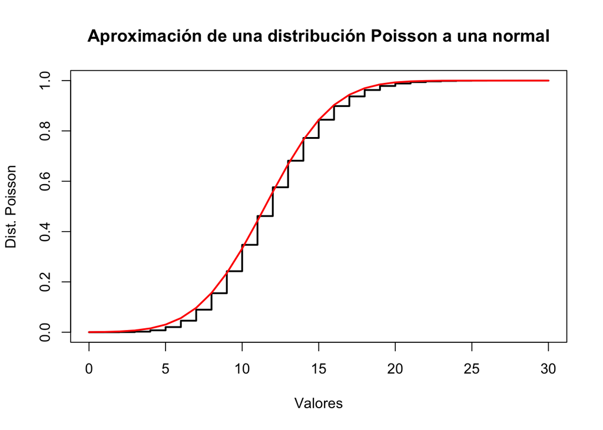

```r
lambda <- 12
valores <- 0:30
pdist <- numeric(length(valores))

for(i in 1:length(valores)){
  pdist[i] <- ppois(valores[i],lambda)
}
plot(valores,pdist,type="s",lwd=2,
     main="Aproximación de una distribución Poisson a una normal",
     xlab="Valores",ylab="Dist. Poisson")

dnorm <- pnorm(valores + 0.5,lambda,sd=sqrt(lambda))
lines(valores,dnorm,col="red",lwd=2)
```

Una variable aleatoria con distribución de Poisson se puede aproximar por una distribución normal cuando el parámetro lambda es grande, generalmente más de 20 (o más de 10 con corrección de continuidad).

## 7. Web scrapping

Obtén de https://quotes.toscrape.com/ las citas de las primeras cinco páginas. Debes recoger en un dataset la cita y el autor.

```r
library(rvest)
citas <- data.frame()
for (i in 1:5) {
  page <- read_html(paste0("https://quotes.toscrape.com/page/", i))
  citas <- rbind(citas,
    data.frame(
      quote = page %>%
        html_elements(".text") %>%
        html_text(),
      author = page %>%
        html_elements(".author") %>%
        html_text(),
      stringsAsFactors = FALSE
    )
  )
}
head(citas,10)
```

```
##                                                                                                                                  quote
## 1                  “The world as we have created it is a process of our thinking. It cannot be changed without changing our thinking.”
## 2                                                “It is our choices, Harry, that show what we truly are, far more than our abilities.”
## 3  “There are only two ways to live your life. One is as though nothing is a miracle. The other is as though everything is a miracle.”
## 4                             “The person, be it gentleman or lady, who has not pleasure in a good novel, must be intolerably stupid.”
## 5                      “Imperfection is beauty, madness is genius and it's better to be absolutely ridiculous than absolutely boring.”
## 6                                                                  “Try not to become a man of success. Rather become a man of value.”
## 7                                                   “It is better to be hated for what you are than to be loved for what you are not.”
## 8                                                                    “I have not failed. I've just found 10,000 ways that won't work.”
## 9                                                “A woman is like a tea bag; you never know how strong it is until it's in hot water.”
## 10                                                                                  “A day without sunshine is like, you know, night.”
##               author
## 1    Albert Einstein
## 2       J.K. Rowling
## 3    Albert Einstein
## 4        Jane Austen
## 5     Marilyn Monroe
## 6    Albert Einstein
## 7         André Gide
## 8   Thomas A. Edison
## 9  Eleanor Roosevelt
## 10      Steve Martin
```